# US Flight Passenger Satisfaction 2015

Sarra Hannachi

23/02/2021

[figure not shown]

# Section 1: Data Description

## Importing Data:

Let us import and explore our data:

```r
US<-read.csv('US airline.csv')
```

```r
US$Gender  <- as.factor(US$Gender)
US$Customer.Type <- as.factor(US$Customer.Type)
US$Type.of.Travel <- as.factor(US$Type.of.Travel)
US$Class <- as.factor(US$Class)
US$satisfaction<- as.factor(US$satisfaction)
head(US)
```

```
##   X    id Gender  Customer.Type Age  Type.of.Travel    Class Flight.Distance
## 1 1 19556 Female Loyal Customer  52 Business travel      Eco             160
## 2 2 90035 Female Loyal Customer  36 Business travel Business            2863
## 5 3 36875 Female Loyal Customer  49 Business travel      Eco            1182
## 6 4 39177   Male Loyal Customer  16 Business travel      Eco             311
## 7 5 79433 Female Loyal Customer  77 Business travel Business            3987
## 8 6 97286 Female Loyal Customer  43 Business travel Business            2556
##   Inflight.wifi.service Departure.Arrival.time.convenient
## 1                     5                                 4
## 2                     1                                 1
## 5                     2                                 3
## 6                     3                                 3
## 7                     5                                 5
## 8                     2                                 2
##   Ease.of.Online.booking Gate.location Food.and.drink Online.boarding
```

[output cut: 27 more lines]

## Introducing Data:

> The dataset of this project contains the results of a Flight Passenger Satisfaction Survey of the year 2015 and it has been collected by US airline. It provides information about the passenger’s flight satisfaction with the US airline. This dataframe is structured with 25 columns where ‘X’ is the observation’s index while the rest 24 represent the attributes that will help assess the satisfaction level of the individuals, and 23863 rows representing the observations from passengers of the US airline.

```r
str(US)
```

```
## 'data.frame':    23863 obs. of  25 variables:
##  $ X                                : int  1 2 3 4 5 6 7 8 9 10 ...
##  $ id                               : int  19556 90035 36875 39177 79433 97286 27508 62482 47583 115550 ...
##  $ Gender                           : Factor w/ 2 levels "Female","Male": 1 1 1 2 1 1 2 1 1 1 ...
##  $ Customer.Type                    : Factor w/ 2 levels "disloyal Customer",..: 2 2 2 2 2 2 2 2 2 2 ...
##  $ Age                              : int  52 36 49 16 77 43 47 46 47 33 ...
##  $ Type.of.Travel                   : Factor w/ 2 levels "Business travel",..: 1 1 1 1 1 1 1 1 1 1 ...
##  $ Class                            : Factor w/ 3 levels "Business","Eco",..: 2 1 2 2 1 1 2 1 2 1 ...
##  $ Flight.Distance                  : int  160 2863 1182 311 3987 2556 556 1744 1235 325 ...
##  $ Inflight.wifi.service            : int  5 1 2 3 5 2 5 2 4 2 ...
##  $ Departure.Arrival.time.convenient: int  4 1 3 3 5 2 2 2 1 5 ...
##  $ Ease.of.Online.booking           : int  3 3 4 3 5 2 2 2 1 5 ...
##  $ Gate.location                    : int  4 1 3 3 5 2 2 2 1 5 ...
##  $ Food.and.drink                   : int  3 5 4 5 3 4 5 3 5 1 ...
##  $ Online.boarding                  : int  4 4 1 5 5 4 5 4 1 3 ...
##  $ Seat.comfort                     : int  3 5 2 3 5 5 5 4 5 4 ...
##  $ Inflight.entertainment           : int  5 4 2 5 5 4 5 4 3 2 ...
##  $ On.board.service                 : int  5 4 2 4 5 4 2 4 3 2 ...
##  $ Leg.room.service                 : int  5 4 2 3 5 4 2 4 4 2 ...
##  $ Baggage.handling                 : int  5 4 2 1 5 4 5 4 3 2 ...
##  $ Checkin.service                  : int  2 3 4 1 4 5 3 5 1 3 ...
##  $ Inflight.service                 : int  5 4 2 2 5 4 3 4 3 2 ...
##  $ Cleanliness                      : int  5 5 4 5 3 3 5 4 4 4 ...
##  $ Departure.Delay.in.Minutes       : int  50 0 0 0 0 77 1 28 29 18 ...
##  $ Arrival.Delay.in.Minutes         : int  44 0 20 0 0 65 0 14 19 7 ...
##  $ satisfaction                     : Factor w/ 2 levels "neutral or dissatisfied",..: 2 2 2 2 2 2 2 2 2 1 ...
```

# Section 2: Problem

> From the US airline’s perspective, we need to study the passengers’ reactions and measurable opinions regarding every sevice that the airline offers for its customers. First, it is important for the airline to make the right decisions that will improve the flights experiences for these passengers. Moreover, the airline needs to reduce the dimensionality of its data to summarize those 24 attributes into a limited number of key features, more understandable and efficient to analyze. More importantly, the company needs to understand its custmomers characteristics to fulfill the specific requirements of each homogenous group in the dataset.

# Section 3: Technical Information

```r
library(naniar)
```

This package helps in structuring and detecting the missing values in data and find the proportion of missing data per each attribute. We need it to select and omit those values because they could affect our analysis badly and tamper with the results.

```r
library(dplyr)
```

This package contains functions that help manipulate data frames. In our case, we will need it mainly for grouping data by a particular variable or to summarize a portion of the data or select specific rows or columns we need under certain conditions that we make.

```r
library(ggplot2)
```

This package’s functions are useful to visualize various types of data in different kind of plots: barplots, piecharts, histograms, etc. We need it in both the Univariate Analysis, as well as the Bivariate analysis to visualize data and the relations between the variables in it.

```r
library (moments)
```

This package contains functions that measure statistical moments. It is helpful in our analysis when computing the skewness measure for particular features from our data to assess its symmetry.

```r
library(ggcorrplot)
```

This package has functions that generate and visualize a correlation matrix. We require this package in the Bivariate Analysis section to study the correlations between our variables and understand the influence that a change in one feature can make on another and eventually on the overall satisfaction of the passengers.

```r
library(FactoMineR)
```

This package contain functions which are crucial for the Principal Components Analysis section. We need it in our data analysis, both to visualize the factor maps and to study our data’s dimensionality and passengers’ satisfaction level orientation.

```r
library(factoextra)
```

This package includes functions which are necessary to perform different clustering techniques on our dataset and to visualize the classification made. We will use it to apply K-means clustering and Hierarchical clustering particularly on our Rensis Likert part of our dataset to identify different groups of the airline’s passengers.

# Section 4: Data Analysis

## I. Data Preparation

- Dealing with missing values:

First, we need to visualize our missing values because we are dealing with a moderately large dataset.

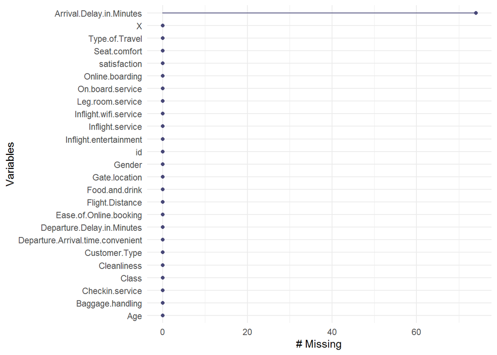

```r
gg_miss_var(US)
```

We can see that the only statistical variable missing values is “Arrival.Delay.in.Minutes” and the number of these values is negligible with respect to the dataframe’s dimensions:

```
## [1] 23863    25
```

But, we still need to drop these few observations because their missing values can influence the outcome of this data’s analysis

```r
sum(is.na(US))
```

```
## [1] 74
```

```r
US=na.omit(US)
sum(is.na(US))
```

```
## [1] 0
```

- Dealing with outliers:

First, we use descriptive statistics to briefly describe each variable and detect the ones that clearly contain outliers in their values because we have an important number of features

```r
summary(US)
```

```
##        X               id            Gender                Customer.Type
##  Min.   :    1   Min.   :    17   Female:12075   disloyal Customer: 3838
##  1st Qu.: 5968   1st Qu.: 32653   Male  :11714   Loyal Customer   :19951
##  Median :11926   Median : 66008
##  Mean   :11932   Mean   : 65323
##  3rd Qu.:17897   3rd Qu.: 97775
##  Max.   :23863   Max.   :129877
##       Age                Type.of.Travel       Class       Flight.Distance
##  Min.   : 7.00   Business travel:16519   Business:11657   Min.   :  31
##  1st Qu.:28.00   Personal Travel: 7270   Eco     :10356   1st Qu.: 446
##  Median :41.00                           Eco Plus: 1776   Median : 874
##  Mean   :40.04                                            Mean   :1229
##  3rd Qu.:52.00                                            3rd Qu.:1796
##  Max.   :85.00                                            Max.   :4983
##  Inflight.wifi.service Departure.Arrival.time.convenient Ease.of.Online.booking
##  Min.   :1.000         Min.   :1.000                     Min.   :1.000
##  1st Qu.:2.000         1st Qu.:2.000                     1st Qu.:2.000
##  Median :3.000         Median :3.000                     Median :3.000
##  Mean   :2.814         Mean   :3.202                     Mean   :2.883
##  3rd Qu.:4.000         3rd Qu.:4.000                     3rd Qu.:4.000
##  Max.   :5.000         Max.   :5.000                     Max.   :5.000
##  Gate.location   Food.and.drink Online.boarding  Seat.comfort
##  Min.   :1.000   Min.   :1.00   Min.   :1.000   Min.   :1.000
##  1st Qu.:2.000   1st Qu.:2.00   1st Qu.:2.000   1st Qu.:2.000
##  Median :3.000   Median :3.00   Median :4.000   Median :4.000
##  Mean   :2.992   Mean   :3.22   Mean   :3.345   Mean   :3.462
##  3rd Qu.:4.000   3rd Qu.:4.00   3rd Qu.:4.000   3rd Qu.:5.000
##  Max.   :5.000   Max.   :5.00   Max.   :5.000   Max.   :5.000
##  Inflight.entertainment On.board.service Leg.room.service Baggage.handling
##  Min.   :1.000          Min.   :1.000    Min.   :1.000    Min.   :1.00
##  1st Qu.:2.000          1st Qu.:2.000    1st Qu.:2.000    1st Qu.:3.00
##  Median :4.000          Median :4.000    Median :4.000    Median :4.00
##  Mean   :3.375          Mean   :3.391    Mean   :3.382    Mean   :3.64
##  3rd Qu.:4.000          3rd Qu.:4.000    3rd Qu.:4.000    3rd Qu.:5.00
##  Max.   :5.000          Max.   :5.000    Max.   :5.000    Max.   :5.00
##  Checkin.service Inflight.service  Cleanliness    Departure.Delay.in.Minutes
##  Min.   :1.000   Min.   :1.000    Min.   :1.000   Min.   :   0.00
##  1st Qu.:3.000   1st Qu.:3.000    1st Qu.:2.000   1st Qu.:   0.00
##  Median :3.000   Median :4.000    Median :3.000   Median :   0.00
##  Mean   :3.306   Mean   :3.655    Mean   :3.292   Mean   :  14.45
##  3rd Qu.:4.000   3rd Qu.:5.000    3rd Qu.:4.000   3rd Qu.:  12.00
##  Max.   :5.000   Max.   :5.000    Max.   :5.000   Max.   :1128.00
##  Arrival.Delay.in.Minutes                  satisfaction
##  Min.   :   0.00          neutral or dissatisfied:13553
##  1st Qu.:   0.00          satisfied              :10236
##  Median :   0.00
##  Mean   :  14.95
##  3rd Qu.:  13.00
##  Max.   :1115.00
```

For the features: **“Flight.Distance”, “Arrival.Delay.in.Minutes” and “Departure.Delay.in.Minutes”** there are noticeable differences between their respective 3rd quantiles and respective maximum values. In order to verify the existence of outliers, we need to visualize them first.

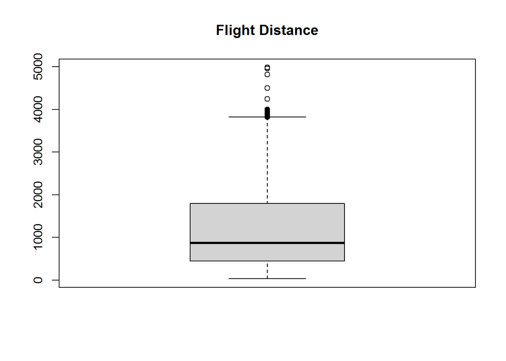

```r
boxplot(US$Flight.Distance, main='Flight Distance')
```

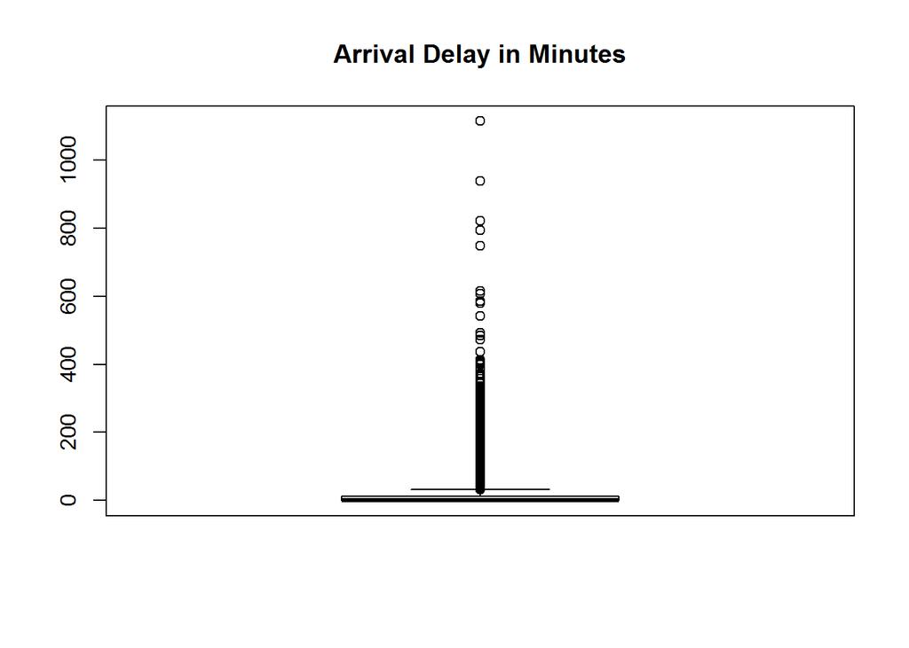

```r
boxplot(US$Arrival.Delay.in.Minutes, main='Arrival Delay in Minutes')
```

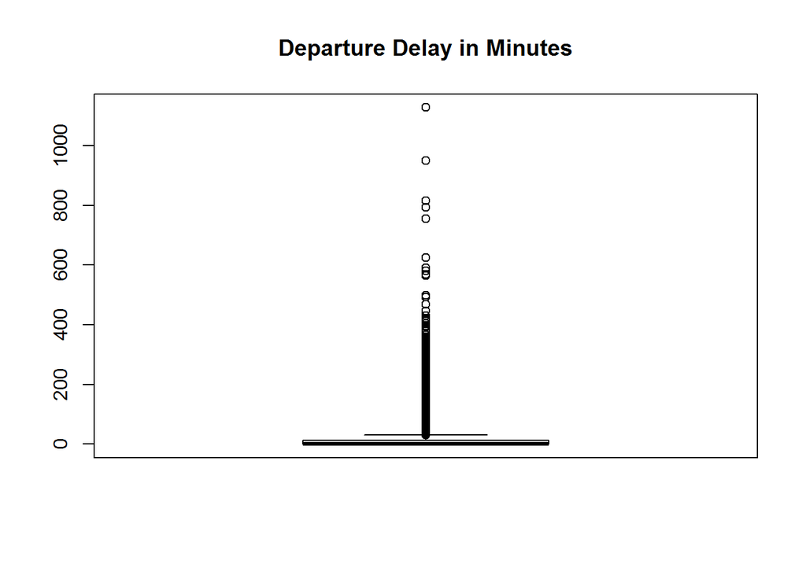

```r
boxplot(US$Departure.Delay.in.Minutes, main = 'Departure Delay in Minutes')
```

Each of these variables have multiple **outliers** with values excluded from the boxplot. We need to find these outliers’ indexes because they are inadequate for our data analysis. In order to do that, first we need to compute the 3 extreme values correspondent to these 3 boxplots.

```r
Ext_FD= summary(US$Flight.Distance)[5]+1.5*(summary(US$Flight.Distance)[5]-summary(US$Flight.Distance)[2])
Ext_ADmins= summary(US$Arrival.Delay.in.Minutes)[5]+1.5*(summary(US$Arrival.Delay.in.Minutes)[5]-summary(US$Arrival.Delay.in.Minutes)[2])
Ext_DDmins= summary(US$Departure.Delay.in.Minutes)[5]+1.5*(summary(US$Departure.Delay.in.Minutes)[5]-summary(US$Departure.Delay.in.Minutes)[2])
```

We can conclude that the anomalous values of the 3 variables regarding the Flight Distance, the Arrival and Departure delays in minutes are the ones larger than these extreme values, respectively.

```r
Outliers_FD <- US$X[US$Flight.Distance > Ext_FD]
Outliers_ADmins <- US$X[US$Arrival.Delay.in.Minutes > Ext_ADmins]
Outliers_DDmins <- US$X[US$Departure.Delay.in.Minutes > Ext_DDmins]
```

We have to remove this important number of anomalous values from our dataset:

```r
US <- subset(US, X %notin% c(Outliers_FD,Outliers_ADmins,Outliers_DDmins))
dim(US)
```

```
## [1] 19605    25
```

Now, we will be analyzing this data with **19605 observations**.

- Verifying imbalance:

We need to check if the outcomes of this satisfaction survey are balanced or not. First, we do that by visualizing the results in a barplot:

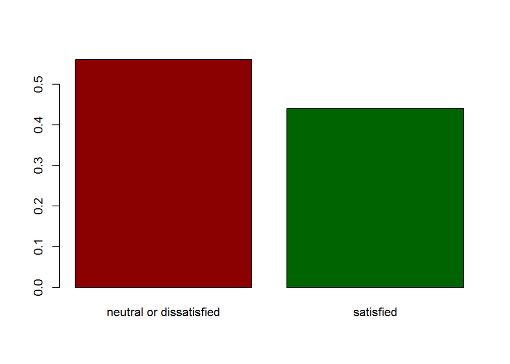

```r
prop.table(table(US$satisfaction))*100
```

```
##
## neutral or dissatisfied               satisfied
##                56.02142                43.97858
```

There are **56.02%** of the passengers who are neutral or dissatisfied while the satisfied individuals represent **43.98%** of the total observations.  
**We can conclude that the flight passengers’ satisfaction outcomes of this survey are more or less balanced which means that our data does not require further sampling or modifications.**

- Testing Normality & Skewness:

We will begin by visualizing the distributions of the cardinal quantitative variables:  
Flight Distance:

```r
#H0: data is normally distributed
#H1: data is not normally distributed
```

We can’t run a Shapiro-Wilk normality test on this variable unless the number of rows is less or equal to **5000**. So, we will mix the data by drawing a sample of **5000** observations from a total of **19605** from **‘Flight.Distance’**.Then, we can run the test:

```r
set.seed(50)
FD_sample= sample(US$Flight.Distance,5000,replace=FALSE)
shapiro.test(FD_sample)
```

```
##
##  Shapiro-Wilk normality test
##
## data:  FD_sample
## W = 0.88216, p-value < 2.2e-16
```

=> The **Shapiro Wlik normality test** of the **‘Flight.Distance’** attribute shows a p-value < 2.2e-16 which is much smaller than 0.01. Hence, we reject H0 at a significance level of alpha=0.01. We are 99% confident that this data **does not** fit a normal distribution. So, we attempt to measure its skewness.

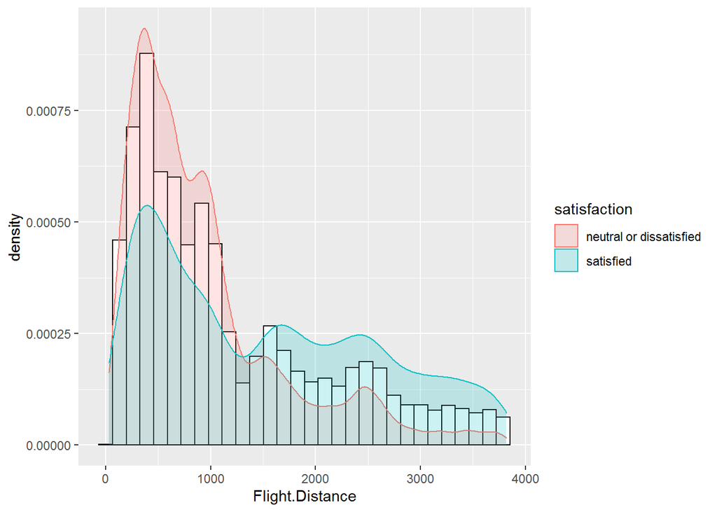

```r
skewness(US$Flight.Distance)
```

```
## [1] 1.005411
```

The density plot clearly confirms the rejection of the null hypothesis, regardless of the passengers’ level of satisfaction. Moreover, the skewness measure of this variable is slightly over **1** which reveals that the data is **positively** skewed.

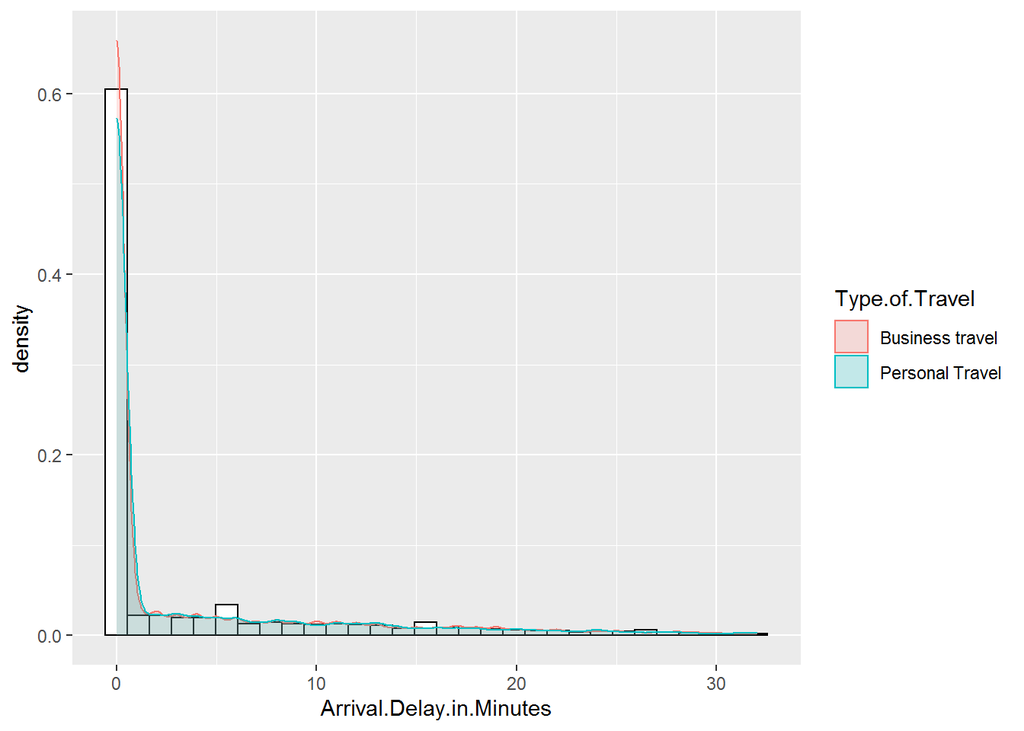

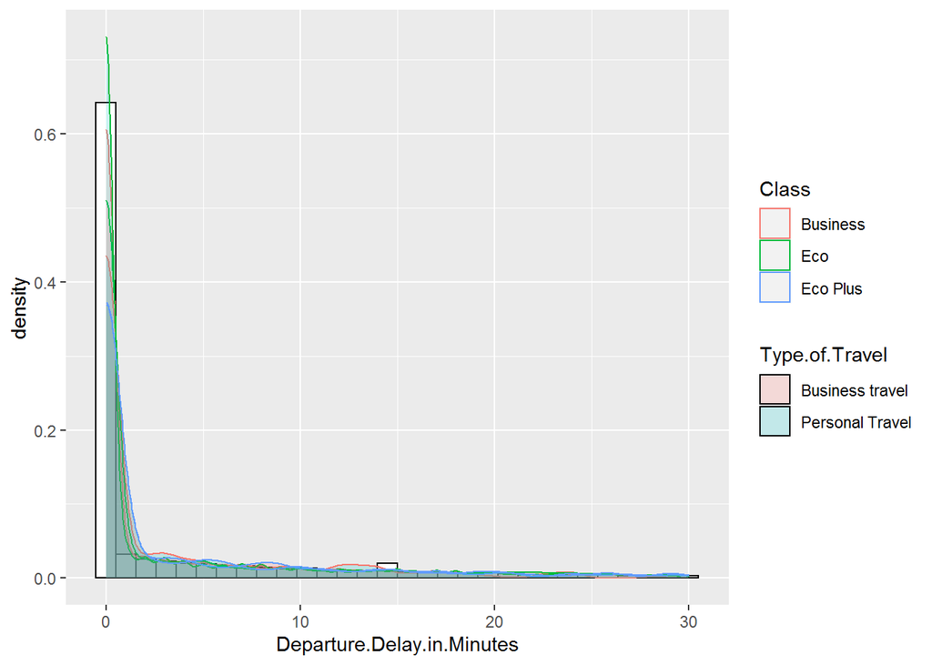

```r
skewness(US$Arrival.Delay.in.Minutes)
```

```
## [1] 2.120143
```

```r
skewness(US$Departure.Delay.in.Minutes)
```

```
## [1] 2.122372
```

After observing these density plots, we can conclude that **‘Arrival.Delay.in.Minutes’ and ‘Departure.Delay.in.Minutes’** are **not normally distributed.** After computing the skewness measure, we can affirm that these two variables are highly right-skewed regardless of the passengers’ type of travel or their flight class. This means that their probabilities distributions are extremely asymmetric across the passengers.  
=>This can be explained by the unlikelihood of having numerous flight delays in an airline with so many years of experience.  
However, the age variable’s distribution is not at all skewed, as it appears below.

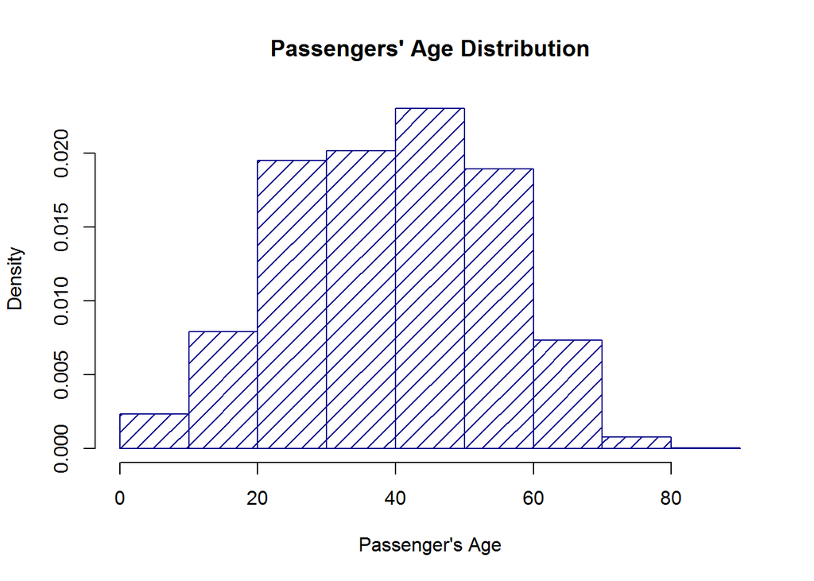

In order to verify, we need to compare the **‘Age’** variable’s median and mean.

```r
Median_mean_difference <- summary(US$Age)[3] - summary(US$Age)[4]
```

```
## [1] "the Median-Mean difference is 0.96 for the Age feature"
```

The difference is less than 1. The mean and median are very close to each other despite the large number of passengers. So, the **‘Age’ is normally distributed.**

> Remark: Our dataset is not small enough to perform a shapiro normality test on the remaining attributes. Besides, the rest of the variables which are ordinal & quantitative are in fact discrete 5-point Rensis Likert scale features with values ranging from 1 to 5. Therefore, they are obviously not normally distributed.

## II. Univariate Exploratory Analysis

We will explore a few variables, especially categorical ones to understand the passengers of this airline better.

> - Gender

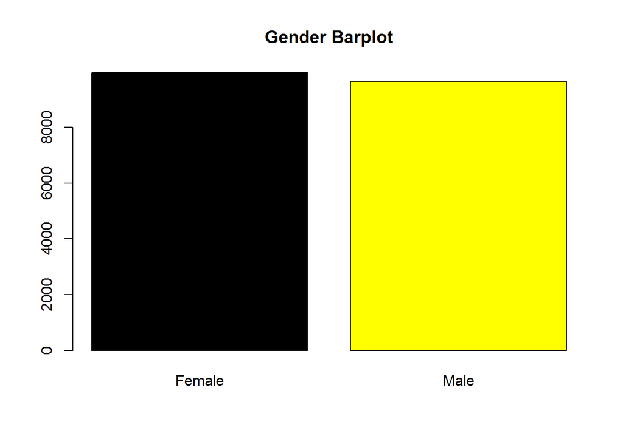

```r
plot(US$Gender,col=c('black','yellow'),main='Gender Barplot')
```

> The data we have about Passenger satisfaction is gender balanced since both genders’ frequencies are more or less equal.
> - Customer Type

```r
prop.table(table(US$Customer.Type))*100
```

```
##
## disloyal Customer    Loyal Customer
##          16.13364          83.86636
```

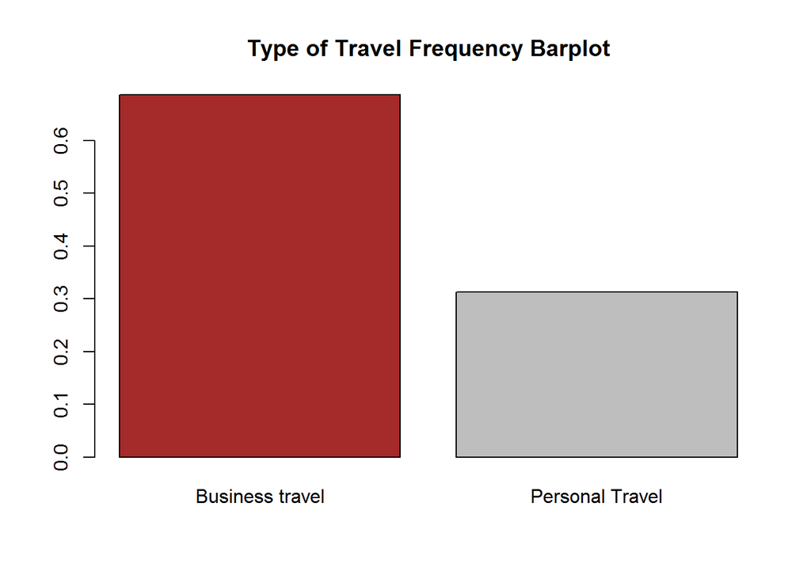

```
##
## Business travel Personal Travel
##        68.69676        31.30324
```

> The majority of this airline’s passengers are customers going on Business trips which could possibly reflect their more serious satisfaction assessment while filling the survey compared to the 31.30% of the passengers who are traveling for pleasure and personal purposes only. We will look into that in the Bivariate Analysis step.
> - Passenger Class

```r
US %>%
    group_by(Class) %>%
    summarize(frequency = n()) %>%
    arrange(desc(frequency)) %>%
    mutate(relative_frequency = frequency/sum(frequency),
           cumulative_frequency = cumsum(relative_frequency))
```

```
## # A tibble: 3 x 4
##   Class    frequency relative_frequency cumulative_frequency
##   <fct>        <int>              <dbl>                <dbl>
## 1 Business      9534             0.486                 0.486
## 2 Eco           8604             0.439                 0.925
## 3 Eco Plus      1467             0.0748                1
```

> Reviewing this frequencies table, we conclude that the most common flying classes that the passengers in our data opt for are Business Class or Economic Class. The passengers who fly with an Eco Plus Class only represent about 7.48% of the entire dataset’s observations. Therefore, they don’t impact the overall satisfaction of the airline’s customers as much as Business and Eco passengers do.So, we could conclude that the satisfaction of these passengers who represent 92.5% of the airline’s customers is its priority.
> - Flight Distance

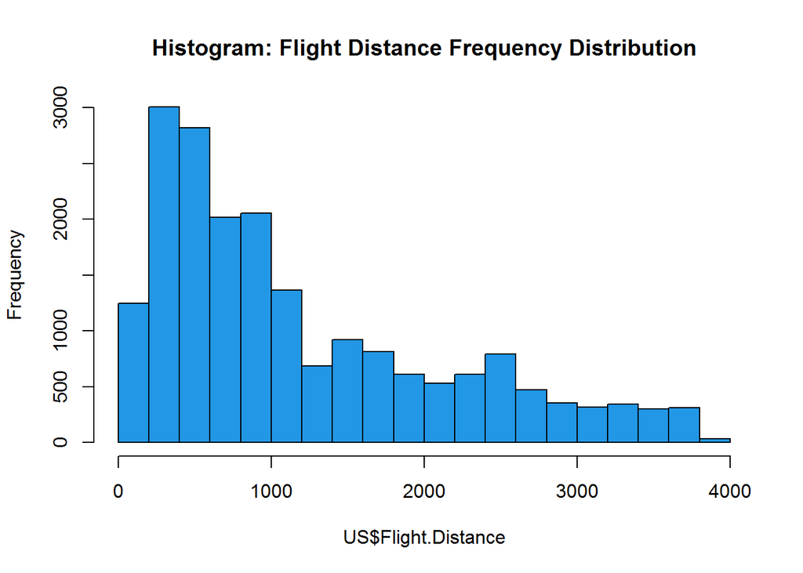

```r
hist(US$Flight.Distance,col=4,
     main='Histogram: Flight Distance Frequency Distribution')
```

## III. Bivariate Exploratory Analysis

> Correlation Matrix

Since most of our data not normally distributed, we should use a **non-parametric correlation test** when generating correlation matrix : **The Spearman coefficient**

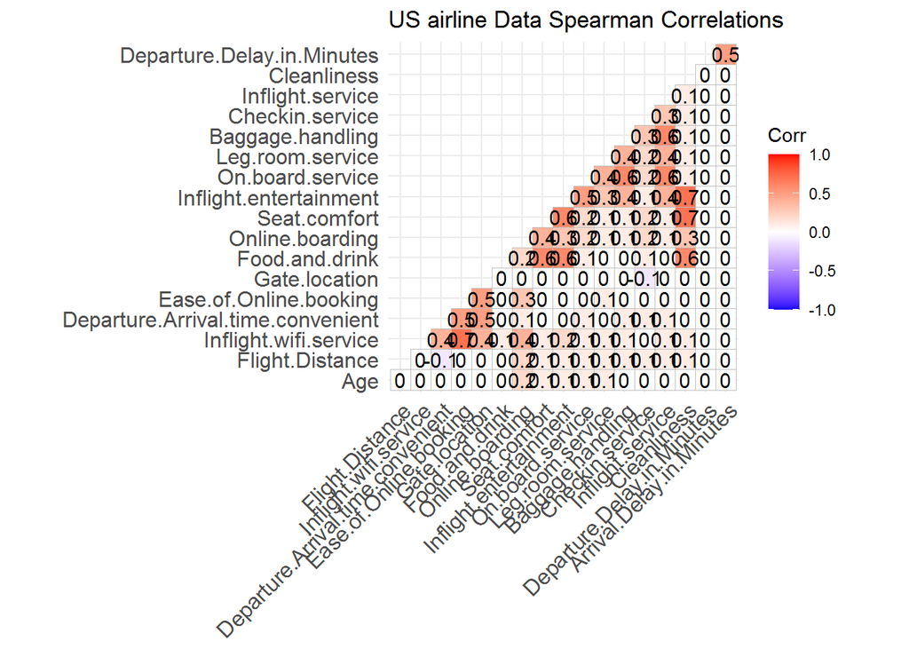

```r
US %>% select(.,is.integer & !starts_with(c('X','id'))) %>%
    cor(.,method='spearman') %>%
    ggcorrplot(type = "lower", digits=1, title='US airline Data Spearman Correlations',lab=T)
```

**This lower-triangle correlation matrix of our numerical data shows that the strongest correlation only exists among the Rensis Likert scale variables, except for a decent correlation between Arrival and Departure delays in Mins of a good coefficient =** *0.5*

> Continuous Variables

To analyze the relations between the different non ordinal quantitative variables, we will run the **Pearson Correlation test** between them respectively:

```r
cor(US$Flight.Distance,US$Arrival.Delay.in.Minutes)
```

```
## [1] -0.01069839
```

```r
cor(US$Flight.Distance,US$Departure.Delay.in.Minutes)
```

```
## [1] 0.008597198
```

The Pearson correlation coefficients are very close to 0.  
**=> There is no correlation between Flight Distance and the two variables “Arrival.Delay.in.Minutes” and “Departure.Delay.in.Minutes” respectively.**

```r
#H0: No relation
#H1: Existence of Relation
cor.test(US$Arrival.Delay.in.Minutes,US$Departure.Delay.in.Minutes,conf.int=T,conf.level = 0.99)
```

```
##
##  Pearson's product-moment correlation
##
## data:  US$Arrival.Delay.in.Minutes and US$Departure.Delay.in.Minutes
## t = 101.98, df = 19603, p-value < 2.2e-16
## alternative hypothesis: true correlation is not equal to 0
## 99 percent confidence interval:
##  0.5766111 0.6006520
## sample estimates:
##       cor
## 0.5887618
```

The p-value is much less than 0.01. So, We reject the null hypothesis H0 and we conclude that we are 99% confident they are positively and quite strongly correlated because the correlation coefficient is the following:

```r
cor(US$Arrival.Delay.in.Minutes,US$Departure.Delay.in.Minutes)
```

```
## [1] 0.5887618
```

**=>This can be explained especially by interconnected flights with at least one stop because one Arrival delay can lead to a Departure delay of another completely different flight from the same airport.**  
>This relation poses the question of comparison of their respective means. Since the data of these two variables is not normally distributed, we shall use the Wilcox Rank Sum Test instead of the Student statistical test.

- Comparing Averages (*Wilcox Rank Sum Test*)

```r
#H0: equal means
#H1: different means
wilcox.test(US$Arrival.Delay.in.Minutes,US$Departure.Delay.in.Minutes,paired=F,
            conf.level=0.99)
```

```
##
##  Wilcoxon rank sum test with continuity correction
##
## data:  US$Arrival.Delay.in.Minutes and US$Departure.Delay.in.Minutes
## W = 192161479, p-value = 0.986
## alternative hypothesis: true location shift is not equal to 0
```

The p-value = 0.986 >> 0.01. So, at a 1% significance level, we accept H0.  
**=> We are 99% confident that Arrival and Departure Delays features have similar means.**

- Analysis of Variances (*ANOVA TEST*)

```r
#H0: equal variances: Var(Arr) == Var(Dep)
#H1: different variances: Var(Arr) != Var(Dep)
var.test(US$Arrival.Delay.in.Minutes,US$Departure.Delay.in.Minutes,paired=F,
         conf.level=0.99)
```

```
##
##  F test to compare two variances
##
## data:  US$Arrival.Delay.in.Minutes and US$Departure.Delay.in.Minutes
## F = 1.0324, num df = 19604, denom df = 19604, p-value = 0.02554
## alternative hypothesis: true ratio of variances is not equal to 1
## 99 percent confidence interval:
##  0.9951159 1.0711090
## sample estimates:
## ratio of variances
##           1.032413
```

=> The p-value = 0.026 > 0.01. So, we accept H0 at a 1% significance level and we conclude that we are 99% confident these two variables have equal variances. Also, We can see that the upper and lower bounds of the confidence interval are both extremely close to 1.**Therefore, both variables have similar dispersion of their respective values.**

> Continuous / Categorical

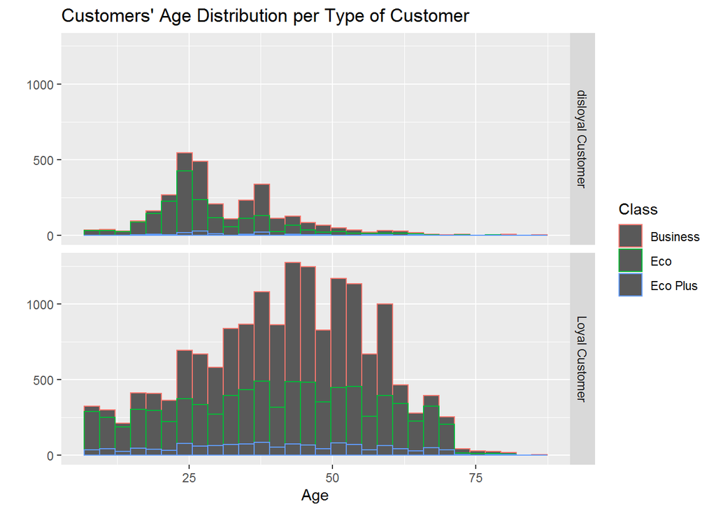

```r
qplot(Age,data=US,color=Class,main="Customers' Age Distribution per Type of Customer") + facet_grid(Customer.Type ~ .)
```

We can see that the most loyal customers are passengers in their **mid-40s & mid-50s** while the most disloyal customers are in their **mid-20s.** This can be explained with the familiarity of traveling with the airline in the past and the trust that was built in time between the passengers and the American Airline.

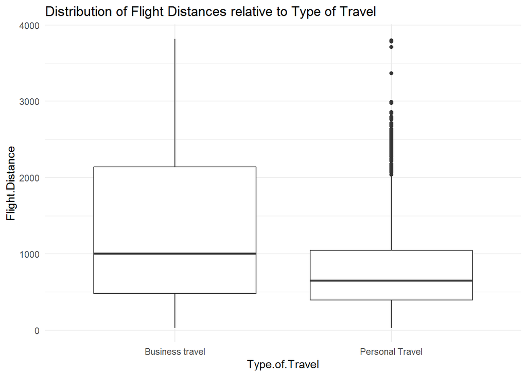

```r
US %>% ggplot(aes(Type.of.Travel,Flight.Distance)) +
    geom_boxplot() +
    labs(title = "Distribution of Flight Distances relative to Type of Travel") +
    theme_minimal()
```

By visualizing these box plots, we can detect a large difference between the data distribution of “Flight.Distance” for the 2 types of Travel. About **75%** of the passengers traveling for Business book flights of less than **2000 miles** while the same percentage of those on personal trips choose to take flights of less than **1000 miles only.**  
>This illustrates that the majority of the passengers’ don’t like to bother taking long flights to far destinations when their travel purpose is merely pleasure and personal affairs. Most of the time, it’s Business travel passengers who are willing to take extremely long flights because it’s work related and they may not have a choice.

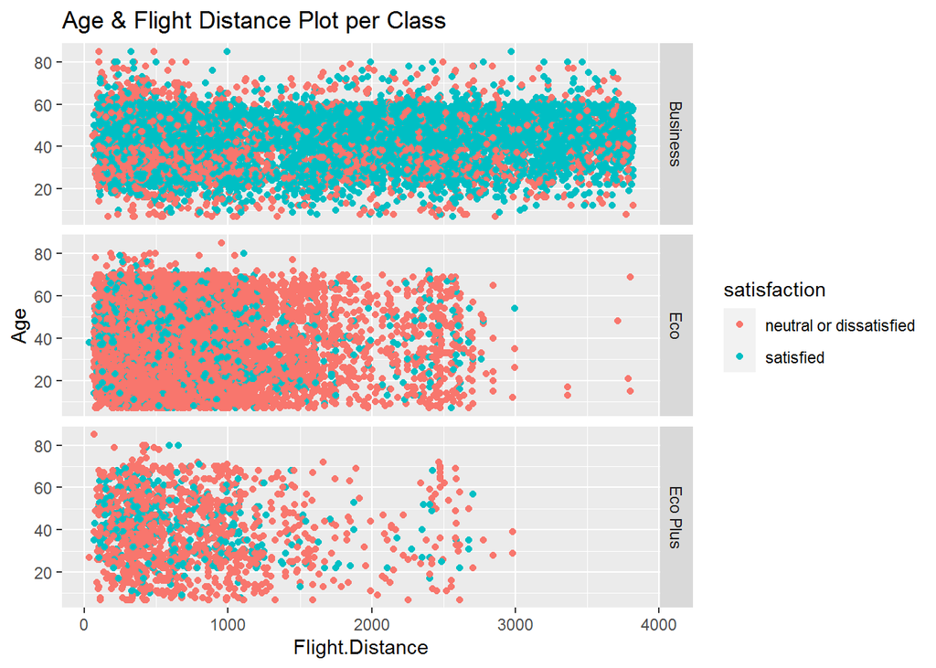

```r
qplot(Flight.Distance,Age,data=US,color=satisfaction,
               main='Age & Flight Distance Plot per Class') + facet_grid(Class~.)
```

The scatter plot is horizontal for all different flight classes possible which means it’s a linear relationship with a zero slope. **Hence, there is no correlation between the two variables Age and Flight Distance.**  
The only relation we can suspect through this plot is the one between the flight class and the passengers’ satisfaction levels. We will tackle that in the next part.

> Categorical

In this case, to perform the **bivariate analysis** required, we need to structure different contingency tables based on two categorical variables each time:

> - 1st Contingency table: Class / satisfaction

```r
Class_satisf <- table(US$satisfaction,US$Class)
Class_satisf
```

```
##
##                           Business  Eco Eco Plus
##   neutral or dissatisfied     2871 7000     1112
##   satisfied                   6663 1604      355
```

```r
#H0: Absence of relationship
#H1: Relationship existence
chisq.test(Class_satisf)
```

```
##
##  Pearson's Chi-squared test
##
## data:  Class_satisf
## X-squared = 5072.2, df = 2, p-value < 2.2e-16
```

After performing the Chi square test, we see that the p-value < 2.2e-16 << 0.01 So, we reject the null hypothesis. There is a relationship between the two categorical variables and we need to compute Cramer’s V in order to measure this relation.

```r
n=sum(Class_satisf)
l=length(rownames(Class_satisf))
c=length(rownames(Class_satisf))
chi2=summary(Class_satisf)$statistic
paste("The Chi square for the 1st contingency table is ",chi2)
```

```
## [1] "The Chi square for the 1st contingency table is  5072.16778681002"
```

```r
V = sqrt(chi2/(n*min(l-1,c-1)))
V
```

```
## [1] 0.5086434
```

The test outputs V=0.51 => **The relationship between Class and Satisfaction is moderately strong** where the Business Class passengers are mostly satisfied while the majority of Eco and Eco Plus passengers are neutral/dissatisfied with the airline, overall.  
We perform the exact same test on the lasting contingency tables:

> - 2nd Contingency table: Satisfaction / Customer type

```r
loyalty <- table(US$Customer.Type,US$satisfaction)
loyalty
```

```
##
##                     neutral or dissatisfied satisfied
##   disloyal Customer                    2530       633
##   Loyal Customer                       8453      7989
```

```r
#H0: Absence of relationship
#H1: Relationship existence
chisq.test(loyalty)
```

```
##
##  Pearson's Chi-squared test with Yates' continuity correction
##
## data:  loyalty
## X-squared = 878.07, df = 1, p-value < 2.2e-16
```

p-value < 2.2e-16 => We reject H0.

```r
n2=sum(loyalty)
l2=length(rownames(loyalty))
c2=length(rownames(loyalty))
chi2_loyalty=summary(loyalty)$statistic
paste("The Chi square for the 1st contingency table is ",chi2_loyalty)
```

```
## [1] "The Chi square for the 1st contingency table is  879.234423613683"
```

```r
V2 = sqrt(chi2_loyalty/(n*min(l-1,c-1)))
V2
```

```
## [1] 0.2117722
```

There exist a relationship but it is a **very weak** one between the type of customer’s and their satisfaction because V=0.21

> - 3rd Contingency table: Type of Travel / Class

```r
travel <- table(US$Class,US$Type.of.Travel)
travel
```

```
##
##            Business travel Personal Travel
##   Business            9128             406
##   Eco                 3585            5019
##   Eco Plus             755             712
```

```r
#H0: Absence of relationship
#H1: Relationship existence
chisq.test(travel)
```

```
##
##  Pearson's Chi-squared test
##
## data:  travel
## X-squared = 6368.6, df = 2, p-value < 2.2e-16
```

p-value < 2.2e-16 => We reject H0.

```r
n3=sum(travel)
l3=length(rownames(travel))
c3=length(rownames(travel))
chi2_travel=summary(travel)$statistic
paste("The Chi square for the 3rd contingency table is ",chi2_travel)
```

```
## [1] "The Chi square for the 3rd contingency table is  6368.60481865675"
```

```r
V3 = sqrt(chi2_travel/(n3*min(l3-1,c3-1)))
V3
```

```
## [1] 0.4030173
```

> - 4th Contingency table: Gender / Type of Travel

```r
gender <- table(US$Type.of.Travel,US$Gender)
gender
```

```
##
##                   Female Male
##   Business travel   6940 6528
##   Personal Travel   3017 3120
```

```r
#H0: Absence of relationship
#H1: Relationship existence
chisq.test(gender)
```

```
##
##  Pearson's Chi-squared test with Yates' continuity correction
##
## data:  gender
## X-squared = 9.3698, df = 1, p-value = 0.002206
```

p-value = 0.002 <0.1 => We reject H0.

```r
n4=sum(gender)
l4=length(rownames(gender))
c4=length(rownames(gender))
chi2_gender=summary(gender)$statistic
paste("The Chi square for the 1st contingency table is ",chi2_gender)
```

```
## [1] "The Chi square for the 1st contingency table is  9.46431332802935"
```

```r
V4 = sqrt(chi2_gender/(n4*min(l4-1,c4-1)))
V4
```

```
## [1] 0.02197157
```

> => Remark: In this section, we did not analyze the 5-point Rensis Likert scale variables because we won’t be considering them as continuous variables. We will tackle them in the next section, separately.

## IV. Principal Components Analysis

**We will run a PCA Analysis to reduce dimensionality in our data and to group passengers of the airline into homogeneous clusters in order to study correlation between the Rensis Likert variables of our data better.**  
That is why we have to separate those variables from the our data frame.

```r
Likertscale <- US[,c('Inflight.wifi.service','Departure.Arrival.time.convenient',
                     'Ease.of.Online.booking','Gate.location','Food.and.drink',
                     'Online.boarding','Seat.comfort','Inflight.entertainment',
                     'On.board.service','Leg.room.service','Baggage.handling',
                     'Checkin.service','Inflight.service','Cleanliness')]
head(Likertscale)
```

```
##    Inflight.wifi.service Departure.Arrival.time.convenient
## 2                      1                                 1
## 5                      2                                 3
## 6                      3                                 3
## 9                      5                                 2
## 10                     2                                 2
## 11                     4                                 1
##    Ease.of.Online.booking Gate.location Food.and.drink Online.boarding
## 2                       3             1              5               4
## 5                       4             3              4               1
## 6                       3             3              5               5
## 9                       2             2              5               5
## 10                      2             2              3               4
## 11                      1             1              5               1
##    Seat.comfort Inflight.entertainment On.board.service Leg.room.service
## 2             5                      4                4                4
## 5             2                      2                2                2
## 6             3                      5                4                3
## 9             5                      5                2                2
## 10            4                      4                4                4
## 11            5                      3                3                4
##    Baggage.handling Checkin.service Inflight.service Cleanliness
## 2                 4               3                4           5
## 5                 2               4                2           4
## 6                 1               1                2           5
## 9                 5               3                3           5
## 10                4               5                4           4
## 11                3               1                3           4
```

**In order to clearly visualize the individuals’ opinions on the survey without ommiting valuable observations to our data’s dimensions, we should select a sample of 3000 individuals from our data because they are 19605 passengers.** Then, we run the PCA function:

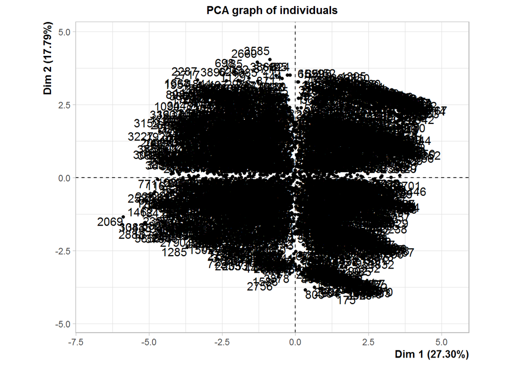

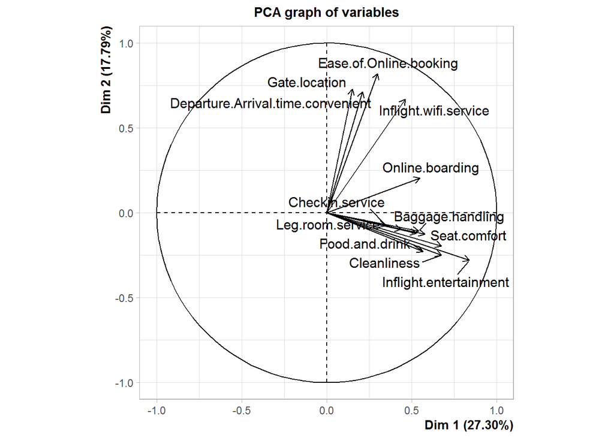

```r
res=PCA(Likertscale[c(1:3000),])
```

```r
res
```

```
## **Results for the Principal Component Analysis (PCA)**
## The analysis was performed on 3000 individuals, described by 14 variables
## *The results are available in the following objects:
##
##    name               description
## 1  "$eig"             "eigenvalues"
## 2  "$var"             "results for the variables"
## 3  "$var$coord"       "coord. for the variables"
## 4  "$var$cor"         "correlations variables - dimensions"
## 5  "$var$cos2"        "cos2 for the variables"
## 6  "$var$contrib"     "contributions of the variables"
## 7  "$ind"             "results for the individuals"
## 8  "$ind$coord"       "coord. for the individuals"
## 9  "$ind$cos2"        "cos2 for the individuals"
## 10 "$ind$contrib"     "contributions of the individuals"
## 11 "$call"            "summary statistics"
## 12 "$call$centre"     "mean of the variables"
## 13 "$call$ecart.type" "standard error of the variables"
## 14 "$call$row.w"      "weights for the individuals"
## 15 "$call$col.w"      "weights for the variables"
```

> Choice of number of axis to retain:

**We will take into consideration both the inertia criterion and the Kaiser criterion with a 70% threshold to make our final choice.**

```r
round(res$eig,2)
```

```
##         eigenvalue percentage of variance cumulative percentage of variance
## comp 1        3.82                  27.30                             27.30
## comp 2        2.49                  17.79                             45.09
## comp 3        2.22                  15.88                             60.97
## comp 4        1.01                   7.24                             68.21
## comp 5        0.93                   6.65                             74.86
## comp 6        0.70                   4.98                             79.83
## comp 7        0.50                   3.56                             83.40
## comp 8        0.44                   3.15                             86.55
## comp 9        0.42                   3.02                             89.57
## comp 10       0.37                   2.63                             92.19
## comp 11       0.34                   2.42                             94.61
## comp 12       0.30                   2.12                             96.73
## comp 13       0.29                   2.06                             98.79
## comp 14       0.17                   1.21                            100.00
```

The first 5 components represent about **74.86%** of the total information. But, only first 4 axis have eigenvalues that are larger than 1.  
=>We will retain the first **3 axis only** because the ratio of explained variance drops from **15.88 to 7.24.**

> Variables Projection Quality Evaluation:

```r
round(res$var$cos2,2)
```

```
##                                   Dim.1 Dim.2 Dim.3 Dim.4 Dim.5
## Inflight.wifi.service              0.21  0.45  0.01  0.05  0.05
## Departure.Arrival.time.convenient  0.04  0.51  0.01  0.10  0.11
## Ease.of.Online.booking             0.09  0.67  0.00  0.02  0.01
## Gate.location                      0.02  0.53  0.00  0.18  0.00
## Food.and.drink                     0.32  0.05  0.31  0.04  0.00
## Online.boarding                    0.30  0.04  0.05  0.43  0.00
## Seat.comfort                       0.46  0.04  0.24  0.00  0.01
## Inflight.entertainment             0.70  0.08  0.03  0.04  0.02
## On.board.service                   0.33  0.02  0.29  0.00  0.00
## Leg.room.service                   0.19  0.01  0.18  0.00  0.12
## Baggage.handling                   0.29  0.01  0.38  0.01  0.00
## Checkin.service                    0.12  0.01  0.08  0.10  0.59
## Inflight.service                   0.28  0.01  0.40  0.02  0.00
## Cleanliness                        0.46  0.06  0.25  0.02  0.01
```

**After observing the cosine square for the 2 first dimensions, if we take 0.6 as our threshold to be selective when comparing sum of cosine squares, we see that the 3 features: Inflight Wifi Service, Inflight entertainment, Ease of Online booking with respective values 0.66, 0.78, 0.76 all have great projection quality on the Principal factor map while the worst projected variables are Checkin service and Leg room service which makes sense because they are the closest ones to the origin of the PCA graph above.**

> Individuals Projection Quality Evaluation:

```r
frame <- as.data.frame(round(res$ind$cos2,2))
frame$Sumcos <- frame$Dim.1+frame$Dim.2
```

**Best projected individuals on the principal factor map (threshold = 0.6):**

```r
Good<-frame[frame$Sumcos>0.6,]
paste("There are", nrow(Good),"very well projected individuals")
```

```
## [1] "There are 849 very well projected individuals"
```

```r
Bad<-frame[frame$Sumcos<0.1,]
paste("There are", nrow(Bad),"very badly projected individuals")
```

```
## [1] "There are 304 very badly projected individuals"
```

They are not many but they are NOT reliable in the principal components analysis.

> Contributions Analysis:

```r
round(res$var$contrib,2)
```

```
##                                   Dim.1 Dim.2 Dim.3 Dim.4 Dim.5
## Inflight.wifi.service              5.57 18.03  0.24  5.03  5.63
## Departure.Arrival.time.convenient  1.16 20.40  0.29  9.98 11.39
## Ease.of.Online.booking             2.35 27.02  0.09  1.76  1.30
## Gate.location                      0.59 21.29  0.15 17.28  0.46
## Food.and.drink                     8.39  2.09 13.79  4.36  0.04
## Online.boarding                    7.87  1.69  2.16 42.11  0.50
## Seat.comfort                      11.94  1.54 10.62  0.02  1.12
## Inflight.entertainment            18.42  3.15  1.14  3.71  2.53
## On.board.service                   8.72  0.63 13.15  0.05  0.02
## Leg.room.service                   4.99  0.38  8.29  0.44 12.64
## Baggage.handling                   7.63  0.47 17.10  0.81  0.06
## Checkin.service                    3.14  0.22  3.75 10.10 62.99
## Inflight.service                   7.30  0.58 18.21  2.29  0.14
## Cleanliness                       11.91  2.51 11.03  2.05  1.19
```

- Principal Components axis identification:

After observing the contributions of each variable for each dimension, we can understand that the features that contribute the most in explaining the first dimension are: The inflight entertainment, seat comfort and cleanliness. So, we could label the **Dim1** as **“Degree of comfort”**.  
As for the 2nd dimension, it is mostly explained by Ease of Online booking, Gate location and Departure & Arrival time convenience. So, the **2nd principal axis** can be labeled as **“Degree of Simplicity & Convenience”.**  
As for the **3rd dimension**, it is mostly explained by the Inflight service and the Baggage handling and also Food & Drink which could both represent this axis as **“Basic service”** which is the minimum that any airline should provide for its customers on any flight.

- Individuals groups identification:

First, we will take a **smaller sample** than the previous to distinguish individuals from each other and identify each group:

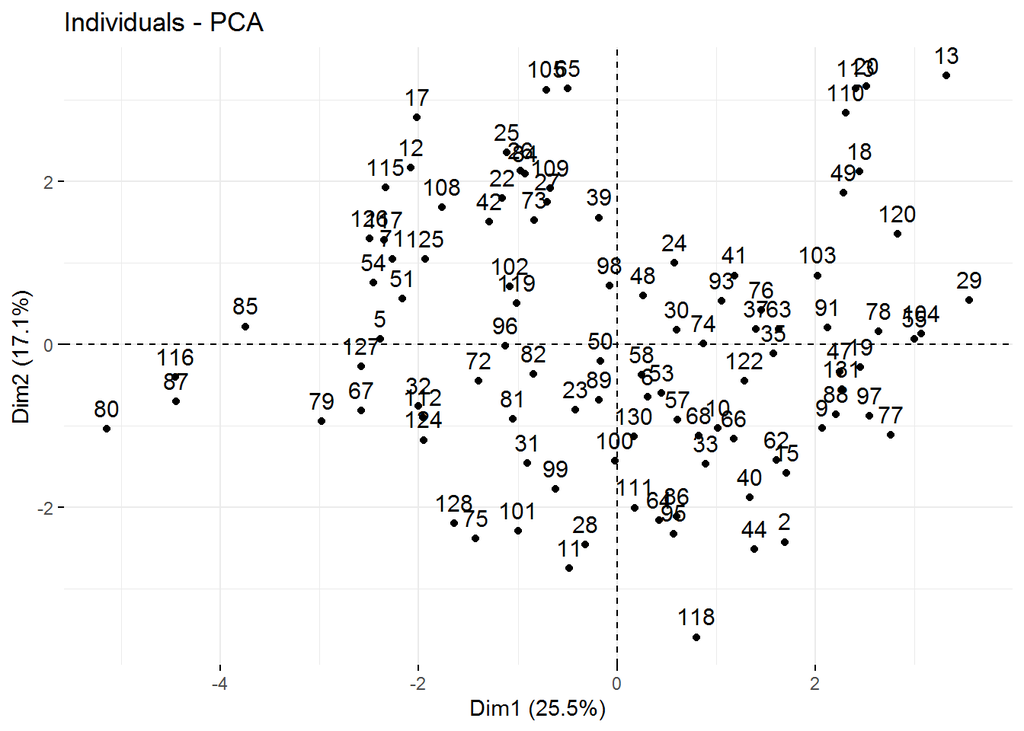

```r
fviz_pca_ind(res_100)
```

Since the passengers are numerous, it is hard to classify the individuals on the PCA graph into different groups. That is why we will opt for some clustering techniques in the next and final section of our Data Analysis.

## V. Clustering

**We will use the data with Rensis Likert scale variables only so we won’t have to standardize or scale our data before applying these next few clustering techniques.**

```r
head(Likertscale)
```

```
##    Inflight.wifi.service Departure.Arrival.time.convenient
## 2                      1                                 1
## 5                      2                                 3
## 6                      3                                 3
## 9                      5                                 2
## 10                     2                                 2
## 11                     4                                 1
##    Ease.of.Online.booking Gate.location Food.and.drink Online.boarding
## 2                       3             1              5               4
## 5                       4             3              4               1
## 6                       3             3              5               5
## 9                       2             2              5               5
## 10                      2             2              3               4
## 11                      1             1              5               1
##    Seat.comfort Inflight.entertainment On.board.service Leg.room.service
## 2             5                      4                4                4
## 5             2                      2                2                2
## 6             3                      5                4                3
## 9             5                      5                2                2
## 10            4                      4                4                4
## 11            5                      3                3                4
##    Baggage.handling Checkin.service Inflight.service Cleanliness
## 2                 4               3                4           5
## 5                 2               4                2           4
## 6                 1               1                2           5
## 9                 5               3                3           5
## 10                4               5                4           4
## 11                3               1                3           4
```

- **HIERARCHICAL Technique**

```r
hir_sample <- Likertscale[c(1:1000),]
```

We can’t select more than **1000** individuals because we need the cluster dendrogram to be clear and vast enough for us to detect the highest jump between clusters.

**Remark: We won’t use the Euclidian method to compute distances because we won’t be considering our Rensis Likert scale data as continious. Therefore, we will opt for the manhattan method which does the sum of all the real distances between a cluster source and a cluster destination:**

```r
D=dist(hir_sample,method = "manhattan")
```

> 1. Clustering with **complete method**

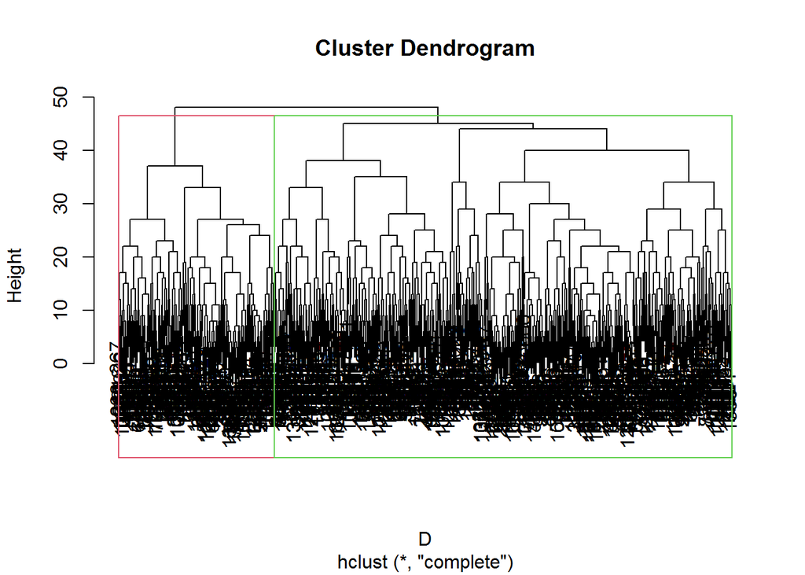

```r
comp=hclust(d=D,method="complete")
plot(comp)
rect.hclust(comp, k = 2, border = 2:5)
```

After observing the highest jump in the Hierarchical Cluster Dendrogram, we cut the tree in the last level into **2 clusters** as follows:

```r
cutree(comp,2)
```

```
##    2    5    6    9   10   11   12   13   15   17   18   19   20   22   23   24
##    1    1    2    2    1    1    1    2    1    1    2    1    2    1    1    1
##   25   26   27   28   29   30   31   32   33   35   37   39   40   41   42   44
##    1    2    2    1    1    1    1    1    2    2    1    1    1    1    1    1
##   47   48   49   50   51   53   54   55   57   58   62   63   64   65   66   67
##    1    1    2    1    1    1    1    2    2    1    1    1    1    2    1    1
##   68   71   72   73   74   75   76   77   78   79   80   81   82   84   85   86
##    1    1    1    1    1    1    1    1    1    1    1    1    1    1    1    2
##   87   88   89   91   93   95   96   97   98   99  100  101  102  103  104  105
##    1    1    1    1    1    1    1    1    1    1    1    1    1    2    1    1
##  108  109  110  111  112  113  115  116  117  118  119  120  122  124  125  126
##    1    2    2    1    1    2    1    1    1    1    1    2    1    1    1    1
##  127  128  130  131  132  133  135  137  138  139  140  141  142  143  144  145
##    1    1    1    1    1    1    2    1    2    1    1    1    2    2    1    1
##  147  148  149  150  151  152  155  156  157  158  159  160  161  162  163  166
```

[output cut: 111 more lines]

Another method we can consider when clustering with hierarchical techniques is Ward:  
> 2. Clustering with **Ward’s minimum variance method**

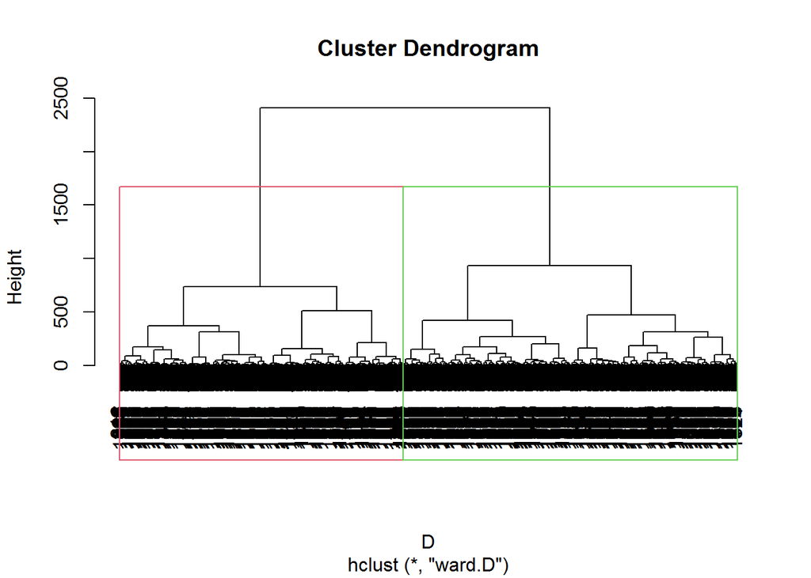

```r
ward=hclust(d=D,method="ward.D")
plot(ward)
rect.hclust(ward, k = 2, border = 2:5)
```

The highest jump in the Hierarchical Cluster Dendrogram is in the last level. So, we cut the clusters tree into **2 clusters** as follows:

```r
cutree(ward,2)
```

```
##    2    5    6    9   10   11   12   13   15   17   18   19   20   22   23   24
##    1    2    1    1    1    2    2    1    1    2    1    1    1    2    2    2
##   25   26   27   28   29   30   31   32   33   35   37   39   40   41   42   44
##    2    2    2    2    1    2    2    2    1    1    1    2    1    1    2    1
##   47   48   49   50   51   53   54   55   57   58   62   63   64   65   66   67
##    1    1    1    2    2    2    2    1    1    2    1    1    2    2    1    2
##   68   71   72   73   74   75   76   77   78   79   80   81   82   84   85   86
##    1    2    2    2    1    2    1    1    1    2    2    2    2    2    2    1
##   87   88   89   91   93   95   96   97   98   99  100  101  102  103  104  105
##    2    1    2    1    1    1    2    1    2    2    2    2    2    1    1    2
##  108  109  110  111  112  113  115  116  117  118  119  120  122  124  125  126
##    2    2    1    1    2    1    2    2    2    1    2    1    1    2    2    2
##  127  128  130  131  132  133  135  137  138  139  140  141  142  143  144  145
##    2    2    1    1    1    1    1    2    1    1    2    2    1    1    2    2
##  147  148  149  150  151  152  155  156  157  158  159  160  161  162  163  166
```

[output cut: 111 more lines]

> 3. Clustering with **Average method**

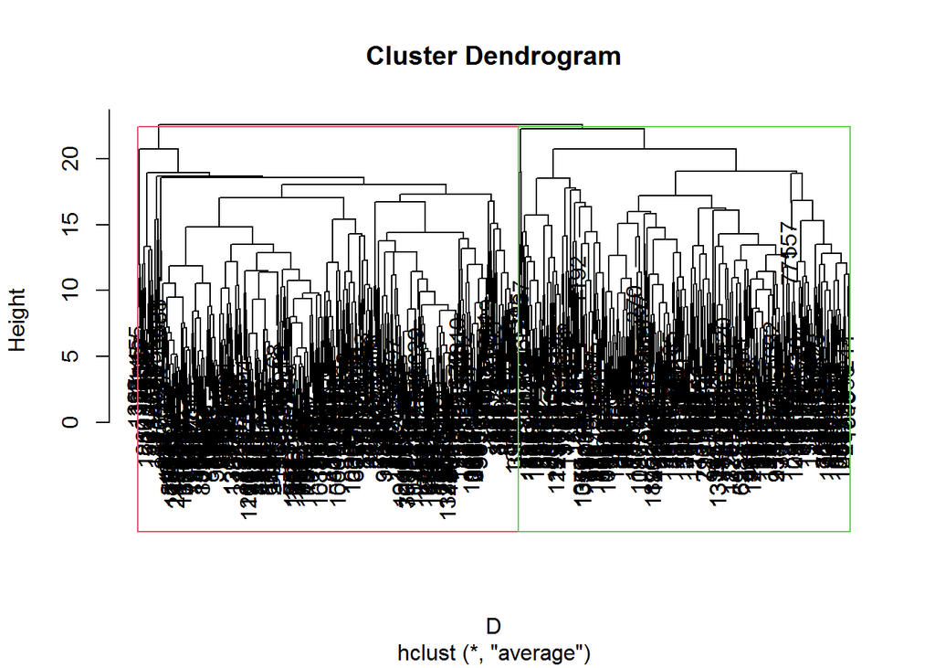

```r
avg=hclust(d=D,method="average")
plot(avg)
rect.hclust(avg, k = 2, border = 2:5)
```

```r
cutree(avg,2)
```

```
##    2    5    6    9   10   11   12   13   15   17   18   19   20   22   23   24
##    1    2    1    1    1    2    2    1    1    2    1    1    1    2    1    1
##   25   26   27   28   29   30   31   32   33   35   37   39   40   41   42   44
##    2    2    2    1    1    1    2    2    1    1    1    2    1    1    2    1
##   47   48   49   50   51   53   54   55   57   58   62   63   64   65   66   67
##    1    1    1    2    2    2    2    1    1    2    1    1    1    1    1    2
##   68   71   72   73   74   75   76   77   78   79   80   81   82   84   85   86
##    1    2    2    2    1    1    1    1    1    2    2    2    2    2    2    1
##   87   88   89   91   93   95   96   97   98   99  100  101  102  103  104  105
##    2    1    2    1    1    1    2    1    2    1    1    2    2    1    1    2
##  108  109  110  111  112  113  115  116  117  118  119  120  122  124  125  126
##    2    2    1    1    2    1    2    2    2    1    2    1    1    2    2    2
##  127  128  130  131  132  133  135  137  138  139  140  141  142  143  144  145
##    2    2    2    1    1    1    1    2    1    1    2    2    1    1    2    2
##  147  148  149  150  151  152  155  156  157  158  159  160  161  162  163  166
```

[output cut: 111 more lines]

Accordingly, many methods of the hierarchical technique suggest that there should be **2 clusters** of the individuals in our data. So, te optimal number of clusters in this **Hierarchical** technique is 2.Then, let’s try to identify them using the **average** method.

First, we will visualize the PCA variables factor map for the sample of Hierarchical technique:

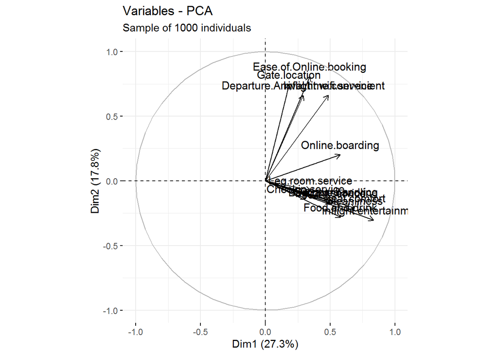

```r
fviz_pca_var(res_1000,subtitle="Sample of 1000 individuals")
```

Second, we will select two individuals from the two different groups detected and we will use their respective data to identify their respective clusters:

```r
cutree(avg,2)[c("2","17")]
```

```
##  2 17
##  1  2
```

```r
hir_sample[cutree(avg,2)["2"][1],]
```

```
##   Inflight.wifi.service Departure.Arrival.time.convenient
## 2                     1                                 1
##   Ease.of.Online.booking Gate.location Food.and.drink Online.boarding
## 2                      3             1              5               4
##   Seat.comfort Inflight.entertainment On.board.service Leg.room.service
## 2            5                      4                4                4
##   Baggage.handling Checkin.service Inflight.service Cleanliness
## 2                4               3                4           5
```

```r
hir_sample[cutree(avg,2)["17"][1],]
```

```
##   Inflight.wifi.service Departure.Arrival.time.convenient
## 5                     2                                 3
##   Ease.of.Online.booking Gate.location Food.and.drink Online.boarding
## 5                      4             3              4               1
##   Seat.comfort Inflight.entertainment On.board.service Leg.room.service
## 5            2                      2                2                2
##   Baggage.handling Checkin.service Inflight.service Cleanliness
## 5                2               4                2           4
```

Now, we will explore the classification of the individuals in our data from a different perspective, using a new clustering technique:

- **K-MEANS Technique**

  **- Elbow Method:**

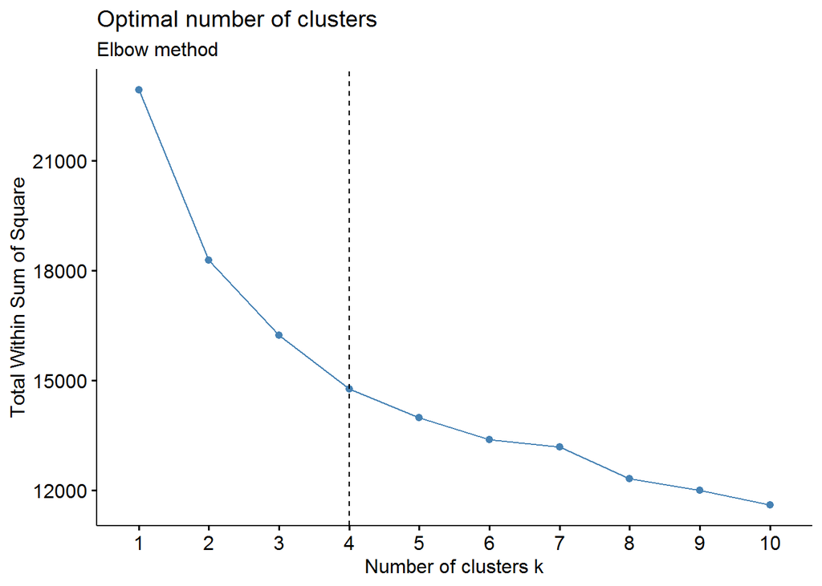

```r
datasample <- Likertscale[c(1:1000),]
fviz_nbclust(datasample, kmeans, method = "wss") +
    geom_vline(xintercept = 4, linetype = 2)+
    labs(subtitle = "Elbow method")
```

**- Silhouette method:**

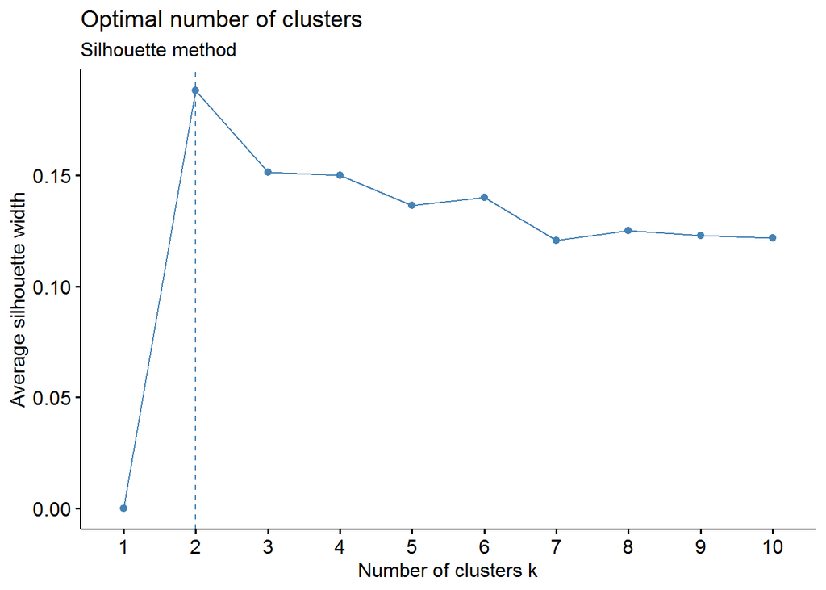

```r
fviz_nbclust(datasample, kmeans, method = "silhouette")+
    labs(subtitle = "Silhouette method")
```

It is clear that the Elbow method implies that the optimal number of clusters is **4** while the Silhouette method clearly shows a peak at optimal number of clusters k = **2** So, we will opt for a number of clusters = 3.  
**We can now implement k means clustering technique with k=3:**

```r
three=kmeans(datasample,centers = 3,nstart=25)
three$centers
```

```
##   Inflight.wifi.service Departure.Arrival.time.convenient
## 1              2.312000                          2.573333
## 2              2.472296                          3.055409
## 3              4.280488                          4.341463
##   Ease.of.Online.booking Gate.location Food.and.drink Online.boarding
## 1               2.130667      2.296000       4.024000        3.493333
## 2               2.701847      2.934037       2.205805        2.596306
## 3               4.154472      4.081301       3.735772        4.203252
##   Seat.comfort Inflight.entertainment On.board.service Leg.room.service
## 1     4.221333               4.301333         3.760000         3.549333
## 2     2.372032               2.076517         2.802111         3.071240
## 3     4.186992               4.113821         3.735772         3.788618
##   Baggage.handling Checkin.service Inflight.service Cleanliness
## 1         3.912000        3.525333         3.986667    4.112000
## 2         3.174142        3.000000         3.269129    2.124011
## 3         3.951220        3.565041         3.975610    3.963415
```

> After observing the means of the scales of each variable, we can conclude that we can indeed cluster the individuals in our data into 3 groups:
- Passengers who are satisfied with the **comfort features** where their means are **strictly larger than 3** (such as Seat.comfort, Inflight.entertainment,Leg.room.service Cleanliness and Inflight.service).
- Passengers who are **overall neutral or dissatisfied** with their flights where the cluster means of all features **range in [2.07;3.27]**
- Passengers who are satisfied with the **simplicity and convenience features** where their means are **strictly larger than 3** (such as Inflight.wifi.service, Ease.of.Online.booking, Departure,Arrival.time.convenient, and Gate.location).  
  We can visualize these 3 clusters with the function below:

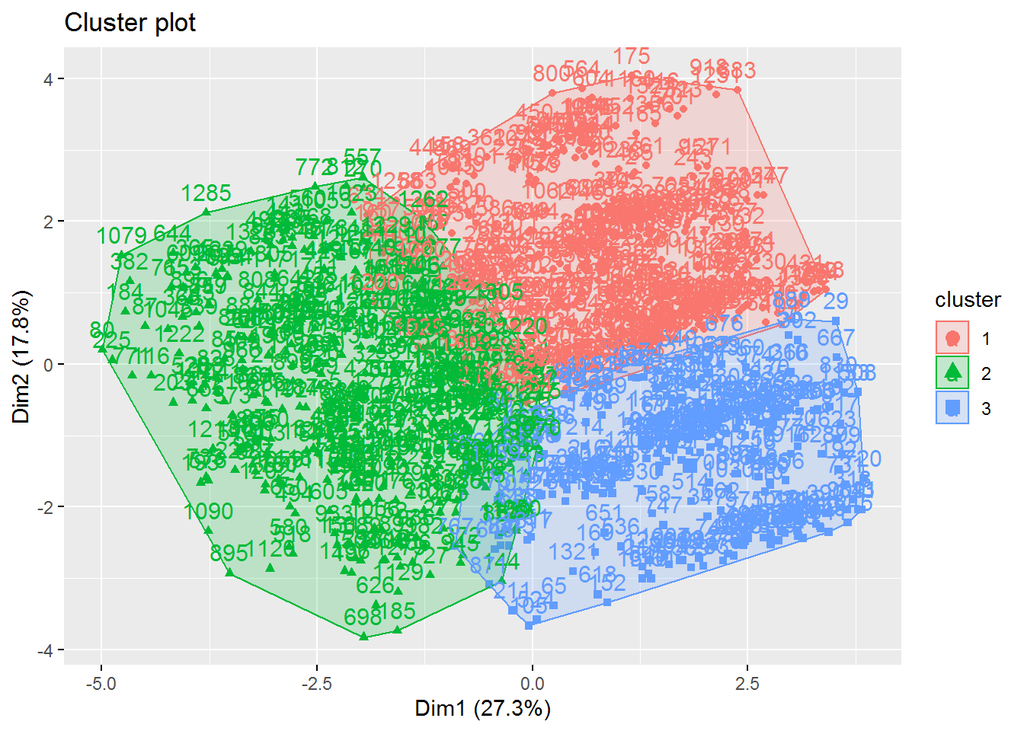

```r
fviz_cluster(three, data = datasample)
```

> In this section, both techniques help idenitify homegneous groups of the airline’s passenger. However, the clusters generated from the K-means technique make more sense and match our dataset better. The airline can now use these clusters to adapt to its customers preferences respectively and satisfy each category of passengers differently.

## Conclusion

- **The airline’s satisfaction survey shed light on the imbalanced structure of its passengers in terms of Flight Class and Loyalty. This caused a problem because around half of the loyal customers are either neutral or dissatisfied. That is why, the company should focus on improving the quality of the services that this portion of the customers are not satisfied with. They are much more important than the disloyal ones, obviously because their flights’ bookings are recurring, so their opinion matters the most. Moreover, the two major flight classes that require full attention are Business Class and Eco because over 90% of their passengers opt for them and also because they have a strong relation with their overall satisfaction level in this survey. The reason behind that could be that the majority of flights have Business purposes not personal one, therefore, the customers can be more critical in their airline service assessment and a bit harder to satisfy.**
- **In addition, The airline can easily group its multiple attributes into 2 or 3 main ones, respectively: *Comfort*, *Simplicity & Convenience* and *Basic Service* because they explain a respectable amount of the total information of the data collected. These 3 key features helps the company look at the big picture and tackle many offered services with one change, one adaptation or one solution for each feature. The PCA Analysis of the 5-point Rensis Likert Scale variables proved the above and clarified the orientation of each group of individuals as well as their level of contentment with particular listed services.**
- **Last but not least, after comparing two different clustering techniques in our analysis, we conclude that the best way that the airline can cluster its passengers is by classifying them into 3 homogeneous groups of individuals: Ones who are satisfied with comfort features, ones who are satisfied with simplicty & convenience features and finally ones who are either neutral or dissatisfied with both types.**